# The Thousand Temples

Monument, Hydraulics, and the Rise of the Pagan Kingdom on the Irrawaddy

Author

Ryan Lafferty

Published

May 4, 2026

## The Empire on the River

The Pagan Kingdom stands as the first polity to bring the territory of modern Myanmar under unified rule. From a bend in the Ayeyarwady known in the chronicles as Arimaddana, the “city that tramples on enemies,” successive kings of the Pagan dynasty built an empire that would last from roughly the 9th century through the catastrophic Mongol campaigns of the late 13th. At its height, the kingdom controlled a territory spanning the central dry zone, the river valleys, and stretches of the Shan highlands to the east, projecting authority through a combination of military power, tributary relationships, and an extraordinary program of religious construction.

The numbers inscribed in the UNESCO designation give a sense of scale: **3,595 monuments** distributed across 8 serial components of the Bagan Archaeological Zone. They were built over roughly four and a half centuries, across approximately 100 square kilometers of the Irrawaddy’s left bank. UNESCO formally inscribed the property in 2019 as a serial cultural landscape, recognizing not just the individual structures but the spatial logic that ties them together: a plain of brick and stucco that reads, from the river or from altitude, as a singular act of concentrated devotion.

The Irrawaddy was not incidental to this achievement. River access meant grain surpluses from the delta, tribute from downstream kingdoms, and movement of the armies that enforced the empire’s borders. The central dry zone, where Bagan sits, receives only about 600 millimeters of rainfall per year, far below the threshold for reliable rain-fed agriculture. The population that supported temple construction did not live on rainfall alone. They built systems.

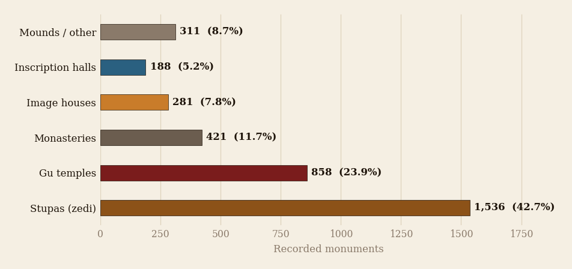

Monument typology at Bagan based on the UNESCO serial property records and the Hudson working database. Stupas account for the largest share, followed by gu-style hollow temples with interior shrine chambers. Total: 3,595 recorded monuments across 8 UNESCO components. Sources: UNESCO WHC property 1588 (2019); Hudson (2008).

## The Monument Field

What makes Bagan unusual among the world’s concentrations of religious architecture is not any single building. It is density. One hundred square kilometers of laterite-rich alluvial plain hold more than three thousand brick structures, ranging from small votive stupas barely taller than a standing person to the great gu temples of the 12th-century building peak: Ananda (monument 2171), Thatbyinnyu, Dhammayangyi, Sulamani (748). The field is not homogeneous. Monuments cluster along the river bluff, around the walled city of Old Bagan, and along the roads that radiated from it, thinning as the plain opens toward the Tuyin Hills to the east.

The typological distinction between stupa and gu temple carries architectural and doctrinal weight. The stupa, or zedi, is a solid form, a reliquary mound, a container of sacred objects and bone relics that accumulates merit for its donor and has no interior accessible to worshippers. The gu temple, by contrast, is a hollow structure with corridors, vestibules, and shrine chambers: a space to walk through and to approach an image. Both forms were built simultaneously throughout the Bagan period, in ratios that shifted with dynastic preference and the sectarian politics of competing Buddhist lineages at court.

The scholarly catalog that underlies modern GIS work on Bagan is the Hudson working database, maintained by archaeologist Bob Hudson under the framework of the Myanmar Department of Archaeology. Hudson’s system assigns each recorded monument a numeric identifier, the same numbers that appear in the published Inventory of Ancient Monuments in Bagan (DoA, multiple volumes from 1998), and records location, typology, century of construction, and conservation condition. CyArk, in partnership with Carleton University and the Google Cultural Institute, ran photogrammetric and LiDAR capture campaigns in 2016 and 2017, producing point clouds and textured 3D meshes for hundreds of individual structures. The 2016 campaign was accelerated by the August 2016 earthquake, a magnitude 6.8 event that damaged or destroyed hundreds of structures and triggered urgent documentation work.

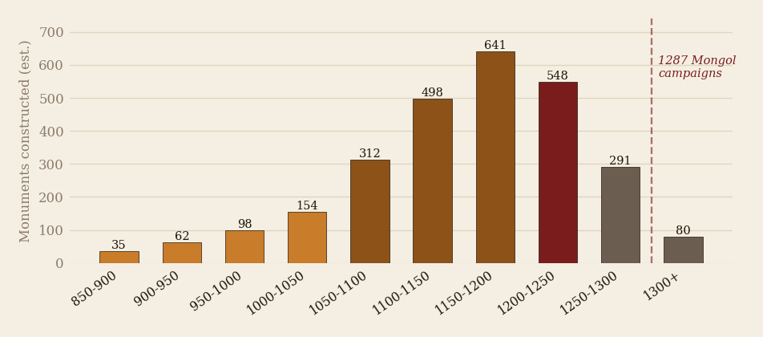

## Hydraulics and the Dry Zone

Bagan sits in the rain shadow of the Arakan Yoma ranges to the west. The central dry zone of Myanmar, roughly the middle Irrawaddy basin between Mandalay and Magwe, receives between 500 and 750 millimeters of annual rainfall, concentrated almost entirely in the June-to-October monsoon window. For a city that at its 12th-century peak may have supported a population of 200,000, the arithmetic of dry-season water supply becomes critical. The temples did not build themselves; the labor, grain, and tribute flows that funded four centuries of brick construction required a settled agricultural population capable of producing surplus, year after year, in one of the driest zones in mainland Southeast Asia.

The hydraulic response was irrigation. Bagan’s kings invested in weirs, diversions, and storage tanks fed by seasonal watercourses draining the Arakan foothills and the Tuyin Hills east of the plain. The Mon and Pyu irrigation traditions that preceded Bagan, and the Burmese engineers who elaborated them, produced a landscape of directed water that is not fully visible from the ground today. Satellite imagery, particularly declassified Corona reconnaissance photographs from the 1960s and contemporary Sentinel-2 and SRTM-derived terrain analysis, reveals linear features, berm remnants, and subtle topographic anomalies that correspond to irrigation channels described in Bagan-period inscriptions.

The inscriptions themselves are a data source. Hundreds of Bagan’s stone-inscription slabs, many now housed in the Bagan Archaeological Museum, record donations of land, labor, and water rights alongside temple foundation records. They name specific villages, weirs, and fields. They show that the temple economy and the irrigation economy were the same economy: a king built a temple and simultaneously endowed it with the water rights and agricultural land needed to support the monks who maintained the cult. The temples were not decorative. They were land management institutions.

## The Irrawaddy

The Ayeyarwady, known in the older English literature as the Irrawaddy, is Myanmar’s dominant geographic fact. Running approximately 2,170 kilometers from its confluence sources in the eastern Himalayas near the Chinese border to the Bay of Bengal, the river drains a watershed of roughly 413,000 square kilometers. It falls through gorges in the far north, broadens across the central plain, and fans into a delta of distributary channels before reaching the sea at Yangon’s latitude. The annual discharge at the delta mouth averages around 13,000 cubic meters per second, with a monsoon peak four to five times that figure.

Bagan occupies the left bank of the river at the point where the channel bends east and widens into a broad, braided reach. The city sits on a low bluff above the flood line, elevated enough to avoid routine inundation but close enough to draw water and to move goods, troops, and tribute across the widest internal transport artery in the country. Upriver, the Chindwin joins the Ayeyarwady above Monywa, adding drainage from the western ranges. Downriver, Bagan’s ships could reach the delta port of Bassein in days; upstream, the river gave access to the jade and amber sources of the far north and to the overland routes toward Yunnan.

The river’s behavior in the 13th century was not identical to today’s. Channel migration on braided alluvial systems of this scale is continuous, and the Irrawaddy has shifted its main thread repeatedly since the Bagan period. Some of the western-bank monument clusters visible in the UNESCO serial property may have been served by river access that no longer exists in its original form. HydroSHEDS and HydroRIVERS, derived from SRTM topographic data at 3 arc-second resolution, provide the best current vector representation of the drainage network for GIS work at the regional scale.

## UNESCO and the Zoning Question

UNESCO’s inscription of Bagan as a serial World Heritage property in 2019 came after decades of advocacy and several false starts. The property was repeatedly deferred, partly because of concerns about restoration practices: since the 1990s, the Myanmar government had undertaken concrete-reinforced reconstructions of damaged temples, added modern elevator towers to several monuments for tourist access, and permitted hotel and resort construction within the archaeological zone. These interventions drew sustained criticism from the international heritage community and contributed to UNESCO’s hesitation.

The 2019 inscription as serial property 1588 encompasses 8 components, 7 on the river’s eastern bank and one on the west, with a combined inscribed area covering the core archaeological zone and buffer zones intended to limit development pressure. The spatial logic of the zoning system is the subject of the most rigorous GIS analysis applied to Bagan to date: a satellite study by Edwards, Frasch, and Jeyacheya at Manchester Metropolitan University, published as a Data in Brief companion paper in 2019 (DOI: 10.1016/j.dib.2019.104701), which analyzed Landsat imagery for 8 sample years between 1987 and 2018. Using QGIS and the Hudson monument database, the team generated settlement-extent polygons for each time slice and evaluated how well the zoning boundaries drawn in the UNESCO nomination dossier corresponded to actual land-use change on the ground.

The study’s finding was direct: land-use change, including hotel construction, agricultural intensification, and paved infrastructure, had occurred substantially within the zones nominally protected by the 1998 and 2013 zoning revisions. The buffer zones were not holding. The pattern of encroachment was concentrated along the main tourist access routes and around the three gateways to the zone. The Edwards et al. shapefiles are published as open-access supplementary material on ScienceDirect, making them a directly usable GIS resource for any analysis of the protected area boundary’s effectiveness.

## The 1287 Collapse

The conventional narrative of Bagan’s end, Mongol armies sack the city, temples burn, the kingdom disappears, is a compression that the historical record does not fully support. The Mongol expeditions of 1277 (Ngasaunggyan) and 1287 were real, and they were devastating to Bagan’s military capacity. The kingdom did not survive the 1287 campaign as a going concern, and the capital effectively ceased to function as the seat of an empire. But the temples were not destroyed by the Mongols. The brick and stucco mass of 3,000-plus structures was not something an army of horse-mounted soldiers had any practical means to demolish. The buildings that survive today do so because they were too heavy to move and too numerous to breach.

What the Mongol campaigns destroyed was the tributary system and the royal patronage that had funded temple construction for four centuries. Without central authority to collect and redistribute surplus, the labor force that maintained the monuments dispersed. The population of Bagan contracted sharply, relocating toward Pinya and Sagaing, new centers that emerged in the political vacuum to the north. The city did not empty overnight; some religious activity continued at Bagan’s major temples throughout the 14th and 15th centuries, and the site has never been entirely abandoned.

The historiographical debate concerns the agency of the collapse. Aung-Thwin and others have argued that the Pagan Kingdom’s internal pressures, particularly the alienation of taxable lands to temple endowments, created a fiscal crisis that preceded and enabled the Mongol defeat. On this reading, the campaigns were less a cause than a final external stress on a system already strained to the point of failure. The archaeology does not resolve the question cleanly. What it does show is that the major temples were never systematically dismantled for building material, which implies that the local population maintained enough connection to the site to treat the monuments as protected even during the long, fragmented interregnum between Pagan’s fall and the British annexation of 1885.

## Interactive Map

The map below shows the core Bagan Archaeological Zone centered on Old Bagan at 21.1717°N, 94.8585°E. Once the GIS data fetch script (`Scripts/fetch_bagan_gis.py`) has been run, monument point layers from OSM and the Edwards et al. settlement polygons will be loaded here. The base layer uses Esri World Imagery for context.

The Bagan Archaeological Zone on the left bank of the Irrawaddy. Amber dashed rectangle: approximate UNESCO serial property boundary. Crimson dot: Old Bagan centroid. Amber dots: selected key monuments. Run Scripts/fetch_bagan_gis.py to populate the full OSM monument layer.

[interactive chart not shown]

## Data Notes

The table below catalogs the primary data sources referenced in this report, their access terms, and their relevance to further GIS development of the Bagan project.

[output not shown]

**Coordinate reference:** All GIS work uses EPSG:4326 (WGS84 geographic). For metric-distance analysis, project to UTM Zone 47N (EPSG:32647).

**Bounding box (EPSG:4326):** SW 21.05°N 94.78°E, NE 21.28°N 94.96°E. This covers the core archaeological zone plus Nyaung U to the northeast and New Bagan to the south. For full Pagan Kingdom territorial extent analysis, expand to 18-25°N, 93-98°E.

**MIMU licensing note:** The MIMU Myanmar river network is free with attribution for internal and research use, but online publication as a tile layer or embedded GeoJSON requires prior written agreement from MIMU. For public-facing maps, substitute OSM waterway features or HydroRIVERS.

**Monument count discrepancy:** The UNESCO nomination records 3,595 monuments across 8 serial components. Earlier literature cites counts as high as 4,446 (the figure associated with some interpretations of the Hudson database prior to condition-based exclusions). The 3,595 figure is the current UNESCO-recognized count and is used throughout this report.